# Guess

Julian Ricardo

2019-12-01

AgeGuess.org is a simple on-line game using biological and perceived age as biomarkers to address scientific questions related to aging in humans. The AgeGuess project updates the AgeGuess.org Public Data Set every three months.

#### The Ages

Our jumping-off point for this exploration is comparing the full sets of guesses and actual ages. The shapes of the colored areas below show general agreement between the two sets of ages, with a couple of quirks worth highlighting:

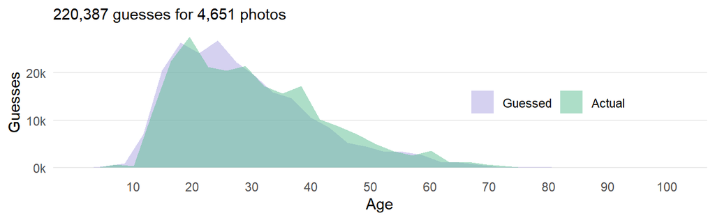

```r
ag_guess %>%
  .[, c("ageG", "ageT")] %>%
  pivot_longer(cols = c(ageG, ageT),
               names_to = "var") %>%
  ggplot(aes(x = value, fill = var)) +
  geom_area(aes(y = ..count..), stat = "bin", bins = 32,
            alpha = 1/2, position = position_dodge()) +
  labs(x = "Age",
       subtitle = paste(comma(length(unique(ag_guess$guess_id))), "guesses for",
                        comma(length(unique(ag_guess$photo_id))), "photos")) +
  scale_x_continuous(name = "Age", breaks = seq(10, 100, 10)) +
  scale_y_continuous(name = "Guesses",
                     labels = comma_format(scale = 1e-3, suffix = "k")) +
  scale_fill_discrete_qualitative(name = NULL,
                                  palette = "Cold",
                                  labels = c("Guessed", "Actual")) +
  theme(legend.position = c(0.75, 0.5),
        legend.direction = "horizontal")
```

- the 20s, where there are more guesses than actual ages
- the post-mid-30s, where the number of actual ages outpaces guessed ages

Taking a second look at the age distributions, both among guesses and actual ages, can deepen our understanding of how they differ. The graph below shows how close the guesses get to the actual age, with a correct guess falling along the grey dotted line.

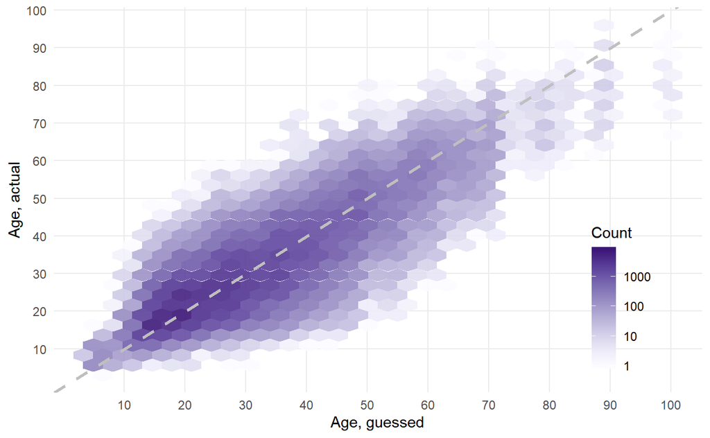

```r
ag_guess %>%
  .[, c("ageG", "ageT")] %>%
  ggplot(aes(x = ageT, y = ageG)) +
  geom_hex(alpha = 1/1.1) +
  geom_abline(slope = 1, intercept = 0,
              color = "grey75", lty = "dashed",
              size = rel(1.1)) +
  scale_x_continuous(name = "Age, guessed", breaks = seq(10, 100, 10)) +
  scale_y_continuous(name = "Age, actual", breaks = seq(10, 100, 10)) +
  scale_fill_continuous_sequential(name = "Count",
                                   palette = "Purples",
                                   trans = "log10") +
  theme(panel.grid.major.x = element_line(),
        legend.position = c(0.875, 0.25))
```

#### The Discrepancies in Ages

Based on all guesses, comparing how far off guesses were (or not) with increasing age of the photographed person

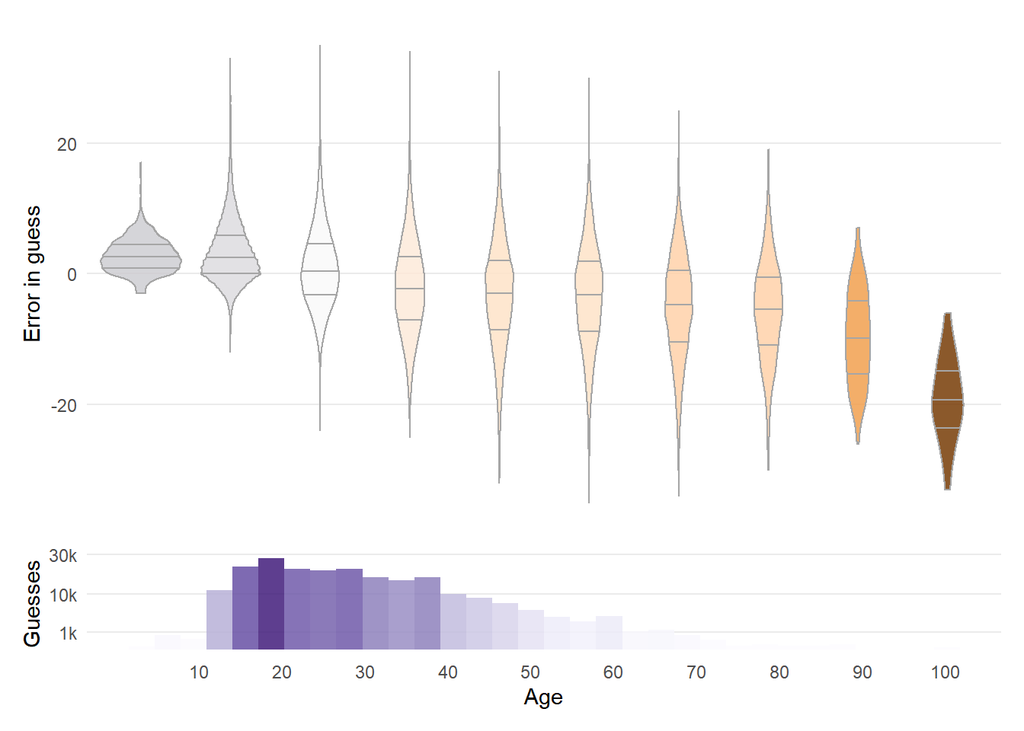

```r
age_discrep_box <-ag_guess %>%
  .[, c("ageT", "outG")] %>%
  .[, decade := factor(floor(ageT/10)*10)] %>%
  .[, outG_median := median(outG), by = "decade"] %>%
  ggplot(aes(x = decade, y = outG)) +
  geom_violin(aes(fill = outG_median),
              alpha = 1/1.2, color = "grey65",
              draw_quantiles = c(0.25, 0.5, 0.75)) +
  scale_fill_continuous_divergingx(palette = "PuOr",
                                   mid = 0,
                                   p3 = 2,
                                   p4 =0.9,
                                   guide = "none") +
  labs(y = "Error in guess")

age_discrep_hist <- ag_guess %>%
  .[, c("ageT", "outG")] %>%
  ggplot(aes(x = ageT)) +
  geom_histogram(aes(fill = ..count..),
                 alpha = 1/1.2,
                 bins = 32) +
  scale_x_continuous(name = "Age", breaks = seq(10, 100, 10)) +
  scale_y_sqrt(name = "Guesses",
               breaks = c(1e3, 1e4, 3e4),
               labels = comma_format(scale = 1e-3,
                                     accuracy = 1,
                                     suffix = "k")) +
  scale_fill_continuous_sequential(palette = "Purples",
                                   guide = "none")

( age_discrep_box +
    theme(axis.text.x = element_blank(),
          axis.title.x = element_blank()) )/
  age_discrep_hist +
  plot_layout(heights = c(5, 1))
```

Then, looking at the same spread of errors when split by…

- the gender the guesssers

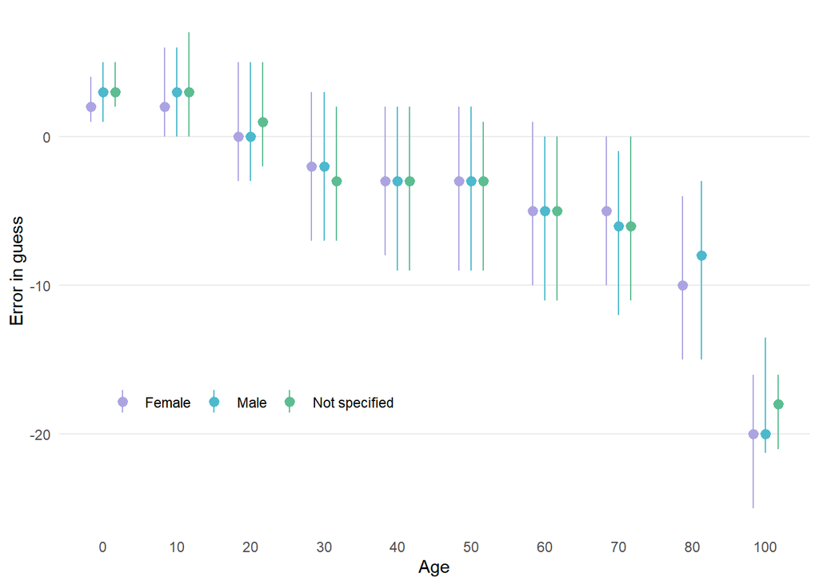

```r
ag_guess[unique(ag_gamers[, c("uid", "gender")]),
                            on = "uid", nomatch = 0] %>%
  .[, c("ageT", "outG", "gender")] %>%
  .[, gender := fct_recode(gender, "Not specified" = "") %>%
      fct_relevel("Not specified", after = Inf)] %>%
  .[, decade := factor(floor(ageT/10)*10)] %>%
  ggplot(aes(x = decade)) +
  stat_summary(
    mapping = aes(y = outG,
                  color = gender),
    fun.ymin = function(z) { quantile(z,0.25) },
    fun.ymax = function(z) { quantile(z,0.75) },
    fun.y = median,
    position = position_dodge(width = 0.5)) +
  scale_color_discrete_qualitative("Cold") +
  labs(x = "Age", y = "Error in guess", color = NULL) +
  theme(legend.position = c(0.25, 0.25),
        legend.direction = "horizontal")
```

- their ethnicity

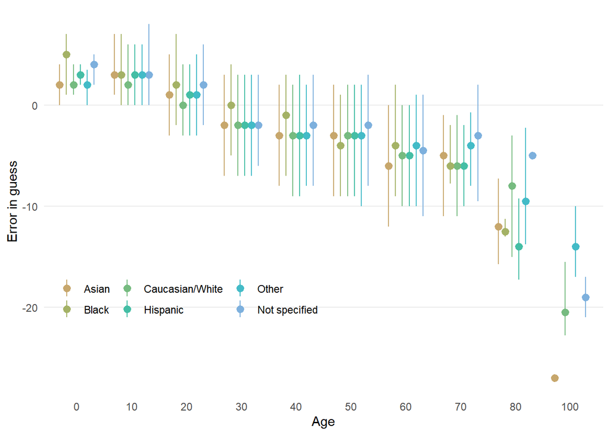

```r
ag_guess[unique(ag_gamers[, c("uid", "ethnicity")]),
                            on = "uid", nomatch = 0] %>%
  .[, c("ageT", "outG", "ethnicity")] %>%
  .[, ethnicity := fct_recode(ethnicity, "Not specified" = "") %>%
      fct_relevel("Not specified", after = Inf)] %>%
  .[, decade := factor(floor(ageT/10)*10)] %>%
  ggplot(aes(x = decade)) +
  stat_summary(aes(y = outG,
                   color = ethnicity),
               fun.ymin = function(z) { quantile(z,0.25) },
               fun.ymax = function(z) { quantile(z,0.75) },
               fun.y = median,
               position = position_dodge(width = 0.75)) +
  scale_color_discrete_qualitative("Harmonic") +
  guides(color = guide_legend(nrow = 2)) +
  labs(x = "Age", y = "Error in guess", color = NULL) +
  theme(legend.position = c(0.25, 0.25),
        legend.direction = "horizontal")
```

- and the year they submitted a guess

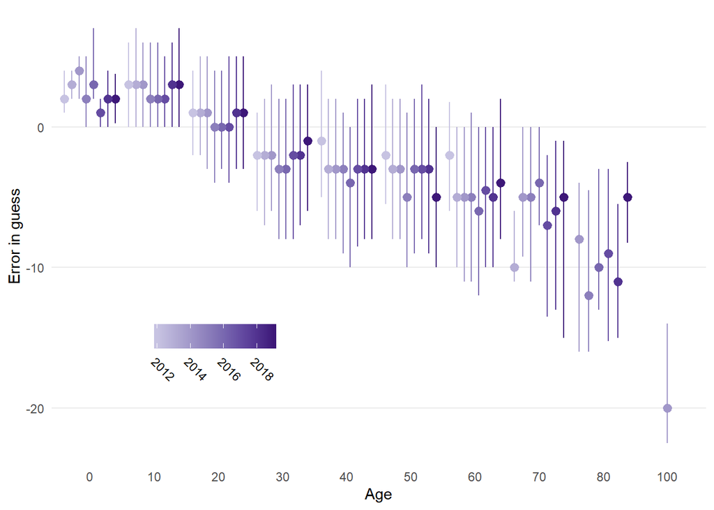

```r
ag_guess %>%
  .[, decade := factor(floor(ageT/10)*10)] %>%
  .[, guess_yr := year(access)] %>%
  ggplot(aes(x = decade)) +
  stat_summary(aes(y = outG,
                   color = guess_yr,
                   group = guess_yr),
               fun.ymin = function(z) { quantile(z,0.25) },
               fun.ymax = function(z) { quantile(z,0.75) },
               fun.y = median,
               position = position_dodge(width = 0.9)) +
  scale_color_continuous_sequential(name = NULL,
                                    palette = "Purples",
                                    begin = 0.333) +
  # Need the line below if adding a title for colorbar
  guides(color = guide_colourbar(title.position = "top")) +
  theme(legend.position = c(0.25, 0.25),
        legend.direction = "horizontal",
        legend.title.align = 0,
        legend.text = element_text(angle = -45),
        legend.text.align = 0) +
  labs(x = "Age", y = "Error in guess")
```